# Group12B_Project_1 (4)

[figure not shown]

### **Group 12B**

###### Usha pavani Thopalle - 989466020

###### Purwa Mugdiya - 989468918

###### Sahana Nagaraj Reddy - 989466865

### **Project Name** : **Student's Mental Health**

#### **Subtitle** : *Analysing and Exploring Demographic Variations in Student Mental Health*

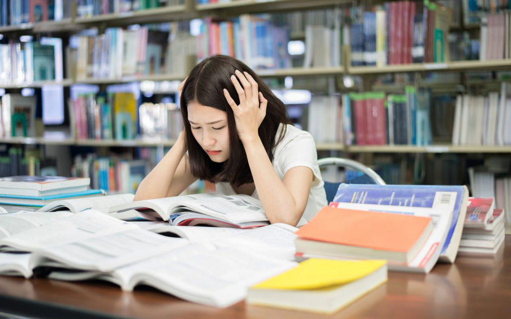

# **1a. Data Selection :**

**Columns Description :**

1. Timestamp - Date and time of the survey taken.
2. Gender - Male or Female.
3. Age - Present Age of the student.
4. Year of Study- Which year the student is studying in?
5. GPA - Student's current score.
6. Depression Status - If the student is depressed? (Yes/No)
7. Anxiety Status - Is the student going through anxiety? (Yes/No)
8. Panic Attack - Is the student having panic attacks? (Yes/No)
9. Treatment Status - Did the student visit any specialist for treatment? (Yes/No)

**Predictions :**

Besides, with additional columns like, stress level, Counselling sessions and updated GPA, will help us understand the current state of the Student's mental health post counselling sessions and whether these sessions helped them improve their academic scores.

# **1b. Stakeholder:**

The Stakeholder for the mentioned project is "**US Secretary of Education**". This research will help the Secretary to understand how the Student's mental health is affected due to the increased academic structure and less of the social events and activities. Moreover, it will showcase how important it is for the education sector to organize the counselling sessions to improve the students health and academic scores.

# **1c. Objective of the Proposed Research**

##### The research involves understanding and identifying student’s mental health, based on their Age, GPA scores, and the amount of stress they are going through because of their day-to-day activities. Figuring out the improvement based on their counselling sessions by implementing various qualitative and quantitative methods to the given data.

##### This study is based on the performance of the students in their academics, calculating their stress levels based on the three aspects – Depression, Panic attacks, and Anxiety and how this has affected their academics and concerns extended to family members and loved ones.

###### Below packages are installed to perform various Data Manipulation activies, linear Regression and creating plots.

```python
#installing dplyr package
install.packages("dplyr")
library(dplyr)
#instlling tidyverse package
install.packages("tidyr")
library(tidyr)
suppressPackageStartupMessages(library(ggplot2))
install.packages("scatterplot3d")
library(scatterplot3d)
install.packages("plotly")
library(plotly)
install.packages("ggcorrplot")
library(ggcorrplot)
install.packages("plot3D")
library(plot3D)
install.packages("plotrix")
library(plotrix)
install.packages("lattice")
library(lattice)
install.packages("reshape2")
library(reshape2)
install.packages("psych")
library(psych)
```

```python
student_df <- read.csv("/content/Student Mental Health (3).csv")
head(student_df[c("Gender","Age","Course","GPA","Counselling.sessions","Counselling.Range","Depression.Range","Anxiety.Range","Panic.Attack.Range")], 3)
```

A data.frame: 3 × 9

|  | Gender <chr> | Age <int> | Course <chr> | GPA <dbl> | Counselling.sessions <chr> | Counselling.Range <int> | Depression.Range <dbl> | Anxiety.Range <dbl> | Panic.Attack.Range <dbl> |
| --- | --- | --- | --- | --- | --- | --- | --- | --- | --- |
| 1 | Female | 18 | Engineering | 3 | Yes | 6 | 7.1 | 6.8 | 6.2 |
| 2 | Male | 21 | Islamic education | 3 | No | 3 | 1.2 | 9.2 | 6.3 |
| 3 | Male | 19 | BIT | 3 | No | 4 | 8.3 | 9.6 | 7.2 |

# **2 Data Exploration :**

In this section, get the detailed insights about the data by performing some qualitative methods.

1. Fetching the sample number of rows from the dataset
2. Displaying the number of rows and columns in the dataset.
3. Showcasing the Dimensions and summary of the data.
4. Getting the glimpse of the data.

```python
nrow(student_df)
```

101

```python
ncol(student_df)
```

16

```python
dim(student_df)
```

1. 101

2. 16

```python
summary(student_df)
```

```
  Timestamp            Gender               Age           Course
 Length:101         Length:101         Min.   :18.00   Length:101
 Class :character   Class :character   1st Qu.:18.00   Class :character
 Mode  :character   Mode  :character   Median :19.00   Mode  :character
                                       Mean   :20.53
                                       3rd Qu.:23.00
                                       Max.   :24.00
                                       NA's   :1
 Year.of.Study       GPA        Depression.Status  Anxiety.Status
 Min.   :1.00   Min.   :0.000   Length:101         Length:101
 1st Qu.:1.00   1st Qu.:3.000   Class :character   Class :character
 Median :2.00   Median :3.000   Mode  :character   Mode  :character
 Mean   :1.97   Mean   :3.079
 3rd Qu.:3.00   3rd Qu.:3.500
 Max.   :4.00   Max.   :3.500

 Panic.Attack       Treatment.Status   Counselling.sessions  Current_GPA
 Length:101         Length:101         Length:101           Min.   :1.990
 Class :character   Class :character   Class :character     1st Qu.:3.490
 Mode  :character   Mode  :character   Mode  :character     Median :3.490
                                                            Mean   :3.633
                                                            3rd Qu.:4.000
                                                            Max.   :4.000

 Depression.Range Anxiety.Range    Panic.Attack.Range Counselling.Range
 Min.   :0.300    Min.   : 2.100   Min.   :1.200      Min.   :0.000
 1st Qu.:2.100    1st Qu.: 4.500   1st Qu.:3.400      1st Qu.:3.000
 Median :3.100    Median : 5.900   Median :5.400      Median :5.000
 Mean   :4.539    Mean   : 5.829   Mean   :5.028      Mean   :5.059
 3rd Qu.:7.900    3rd Qu.: 7.200   3rd Qu.:6.300      3rd Qu.:7.000
 Max.   :9.800    Max.   :10.000   Max.   :9.800      Max.   :9.000
```

```python
glimpse(student_df)
```

```
Rows: 101
Columns: 16
$ Timestamp            <chr> "08-07-2020 12:02", "08-07-2020 12:04", "08-07-20…
$ Gender               <chr> "Female", "Male", "Male", "Female", "Male", "Male…
$ Age                  <int> 18, 21, 19, 22, 23, 19, 23, 18, 19, 18, 20, 24, 1…
$ Course               <chr> "Engineering", "Islamic education", "BIT", "Laws"…
$ Year.of.Study        <int> 1, 2, 1, 3, 4, 2, 2, 1, 2, 1, 1, 3, 1, 1, 2, 3, 3…
$ GPA                  <dbl> 3.0, 3.0, 3.0, 3.0, 3.0, 3.5, 3.5, 3.5, 2.5, 3.5,…
$ Depression.Status    <chr> "Yes", "No", "Yes", "Yes", "No", "No", "Yes", "No…
$ Anxiety.Status       <chr> "No", "Yes", "Yes", "No", "No", "No", "No", "Yes"…
$ Panic.Attack         <chr> "Yes", "No", "Yes", "No", "No", "Yes", "Yes", "No…
$ Treatment.Status     <chr> "No", "No", "No", "No", "No", "No", "No", "No", "…
$ Counselling.sessions <chr> "Yes", "No", "No", "Yes", "Yes", "No", "No", "No"…
$ Current_GPA          <dbl> 3.49, 3.49, 3.49, 3.49, 3.49, 4.00, 4.00, 4.00, 2…
$ Depression.Range     <dbl> 7.1, 1.2, 8.3, 8.9, 3.7, 1.3, 9.3, 1.1, 6.4, 3.9,…
$ Anxiety.Range        <dbl> 6.8, 9.2, 9.6, 6.2, 7.2, 5.7, 6.5, 7.4, 8.3, 4.6,…
$ Panic.Attack.Range   <dbl> 6.2, 6.3, 7.2, 5.7, 5.3, 4.2, 5.3, 2.1, 7.2, 4.3,…
$ Counselling.Range    <int> 6, 3, 4, 5, 7, 2, 2, 1, 9, 8, 5, 5, 4, 6, 3, 8, 2…
```

# **3. Data Cleaning:**

In this section, it is identified that this dataset is structured which means no duplicate values, no outliers is present in the dataset, just one missing values row which has been removed with the below code.

```python
Student_clean_data_df <- student_df |> drop_na()
dim(Student_clean_data_df)
```

1. 100

2. 16

# **4. Adaptation :**

In this section, we have created 3 new columns based on the GPA and the mental health data.

```python
# Adding new column based on counsiling session
student_df$Updated_GPA <- ifelse(student_df$Counselling.sessions == "Yes",
                                  student_df$Current_GPA,
                                  student_df$GPA)
head(student_df[c("GPA","Updated_GPA")],3)
```

A data.frame: 3 × 2

|  | GPA <dbl> | Updated_GPA <dbl> |
| --- | --- | --- |
| 1 | 3 | 3.49 |
| 2 | 3 | 3.00 |
| 3 | 3 | 3.00 |

```python
student_df$Improved_GPA <- student_df$Updated_GPA - student_df$GPA
```

```python
df1 <- head(student_df[c("GPA","Updated_GPA","Improved_GPA")],1)
df1
```

A data.frame: 1 × 3

|  | GPA <dbl> | Updated_GPA <dbl> | Improved_GPA <dbl> |
| --- | --- | --- | --- |
| 1 | 3 | 3.49 | 0.49 |

```python
student_df <- student_df %>%
  mutate(Stress_level = case_when(
    Anxiety.Status == "Yes" & Depression.Status == "Yes" & Panic.Attack == "Yes" ~ "High",
    Anxiety.Status == "Yes" & Depression.Status == "Yes" | Panic.Attack == "Yes" & Anxiety.Status == "Yes" |
      Depression.Status == "Yes" & Panic.Attack == "Yes" ~ "Moderate",
    TRUE ~ "Low"
  ))
  head(student_df[c("Depression.Status","Anxiety.Status","Panic.Attack","Stress_level")],3)
```

A data.frame: 3 × 4

|  | Depression.Status <chr> | Anxiety.Status <chr> | Panic.Attack <chr> | Stress_level <chr> |
| --- | --- | --- | --- | --- |
| 1 | Yes | No | Yes | Moderate |
| 2 | No | Yes | No | Low |
| 3 | Yes | Yes | Yes | High |

# **5a. Descriptive Visualization :**

This section is a straightforward way to provide a clear, intuitive and graphical representation of few of the columns in the dataset.

# **5b. Graph Explanation :**

1. **Pie chart** is the representation of the Gender distribution of the students where it shows that there are 74 percent Female and 26 percent male are enrolled for various courses.
2. **Density graph** is to showcase the various range of the Depressions in the students.
3. **Histogram** represents the Age Distribution of the students irrespective of their courses and the the year of their study.
4. **Box Plot** demonstrates the range of the the Age of the students and their Counselling Sessions which is shown in a side by side boxes.
5. Lastly, the **Bar Graph** shows the highly enrolled courses by the students.

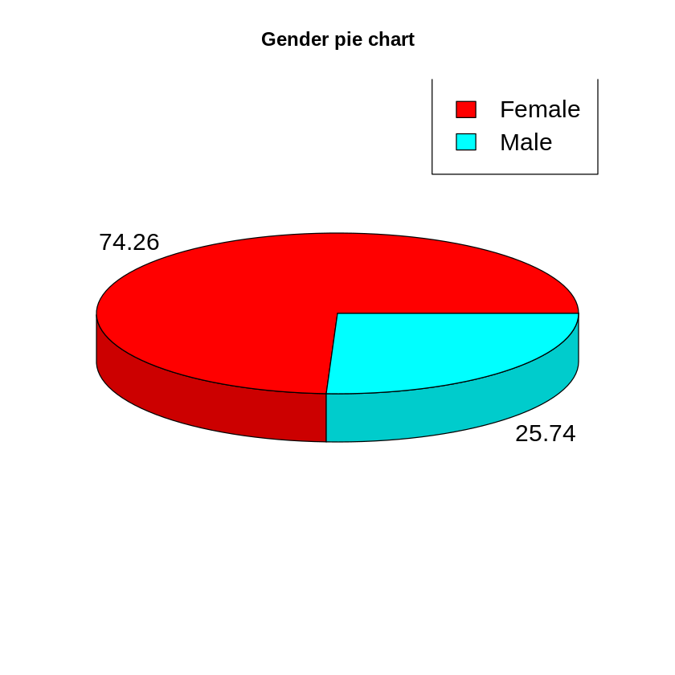

```python
#Pie Chart for Gender Distribution
Gender_plot <- table(student_df$Gender)
piepercent<- round(100 * Gender_plot / sum(Gender_plot), 2)
#piepercent
# Plot the pie chart.
pie3D(Gender_plot, labels = piepercent,
    main = "Gender pie chart", col = rainbow(length(Gender_plot)))
legend("topright", c("Female", "Male"),
                    cex = 1.5, fill = rainbow(length(Gender_plot)))
```

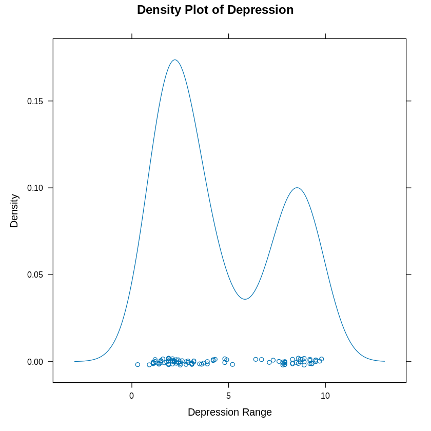

```python
#Density plot for Depression Range
densityplot(student_df$Depression.Range, main = "Density Plot of Depression", xlab = "Depression Range")
```

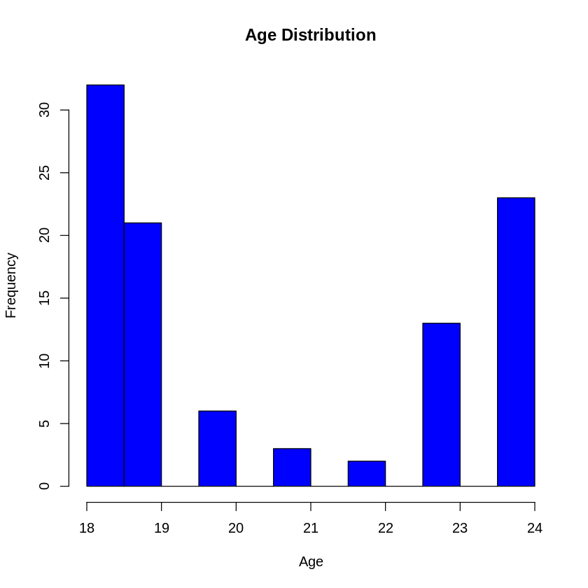

```python
# Histogram for Age distribution
hist(student_df$Age, breaks = 10, col = "blue", main = "Age Distribution", xlab = "Age")
```

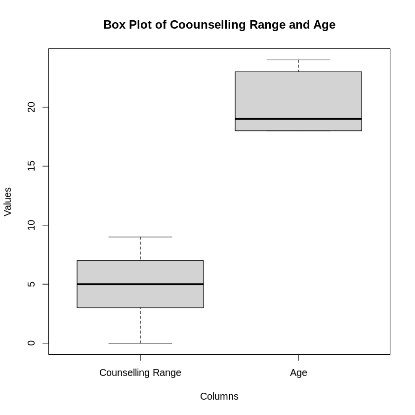

```python
#Create a side-by-side box plot
boxplot(student_df$Counselling.Range, student_df$Age,
        names = c("Counselling Range", "Age"),
        xlab = "Columns", ylab = "Values",
        main = "Box Plot of Coounselling Range and Age")
```

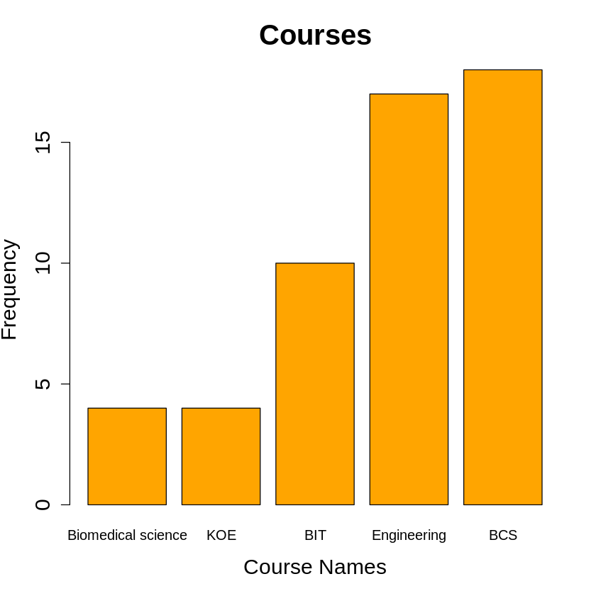

```python
#Displaying highest enrolled Courses
Course_Stress <- student_df |>
                          group_by(Course) |>
                          summarize(Coursecount = n()) |>
                          arrange(desc(Coursecount))
# Bar chart
top_5_Course <- tail(sort(table(student_df$Course)),5)
Graph_Course_Name = names(top_5_Course)
barplot(top_5_Course, main = "Courses",
        names = Graph_Course_Name, xlab = "Course Names", ylab = "Frequency",
        col = "Orange", cex.lab = 1.5, cex.axis = 1.5, cex.main = 2)
```

# **6. Response Variable :**

The formation of the Stress Level is as, suppose all of the three symptoms i.e. Depression, Anxiety and Panic Attack is present in the Student then it is identified as "High Stress", if either of the two symptoms is present then "Moderate Stress" and if student is going through any of the one symptom then it is represented as "Low Stress".

Additionally, a second survey was conducted post their Counselling sessions to understand the improvement in their academic scores. This column is based on the past scores and the couselling sessions.

We hypothesize that both of these columns (Stress Level and Updated GPA) is influenced by the below predictor data:

1. Age
2. Past GPA
3. Depression Status and Range
4. Anxiety Status and Range
5. Panic Attack Status and Range
6. Course

# **7. Explore Correlations:**

This section investigates the relationship between two quantitative variables by using various techniques and identified the correlation amongst them. Also, demonstrates the relation in the form of plots.

0.422371677545111

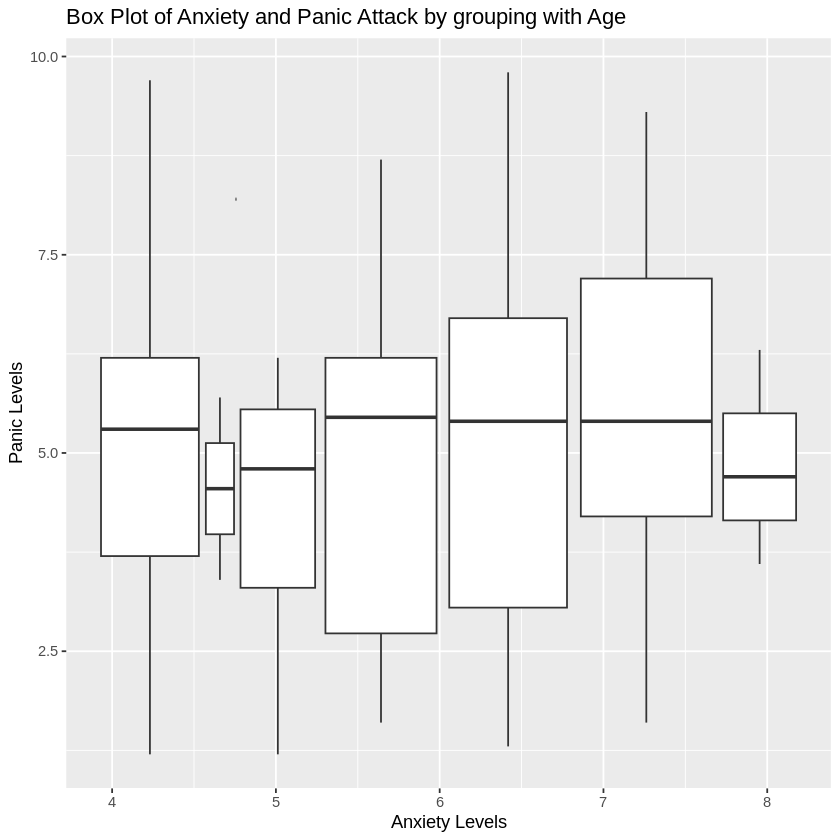

```python
#Box plot for correalation between Anxiety Range and Panic Attack Range
cor(student_df$Anxiety.Range,student_df$Panic.Attack.Range)
ggplot(data = student_df, aes(x = Anxiety.Range, y = Panic.Attack.Range, group = Age)) +
  geom_boxplot() +
  labs(
    title = "Box Plot of Anxiety and Panic Attack by grouping with Age",
    x = "Anxiety Levels",
    y = "Panic Levels"

  )
```

0.315966806880404

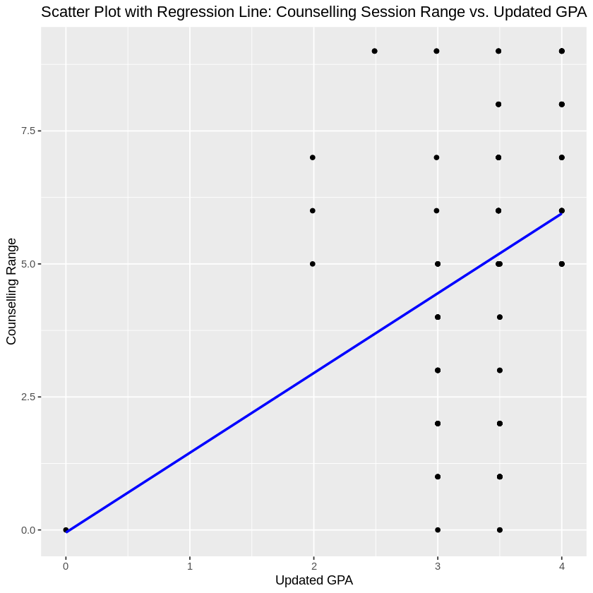

```python
#Scatter Plot for the Counselling Session and Updated GPA
cor(student_df$Updated_GPA,student_df$Counselling.Range)
ggplot(data = student_df, aes(x = Updated_GPA, y = Counselling.Range)) +
  geom_point() +
  geom_smooth(method = "lm", se = FALSE, color = "blue") +
  labs(x = "Updated GPA", y = "Counselling Range") +
  ggtitle("Scatter Plot with Regression Line: Counselling Session Range vs. Updated GPA")
```

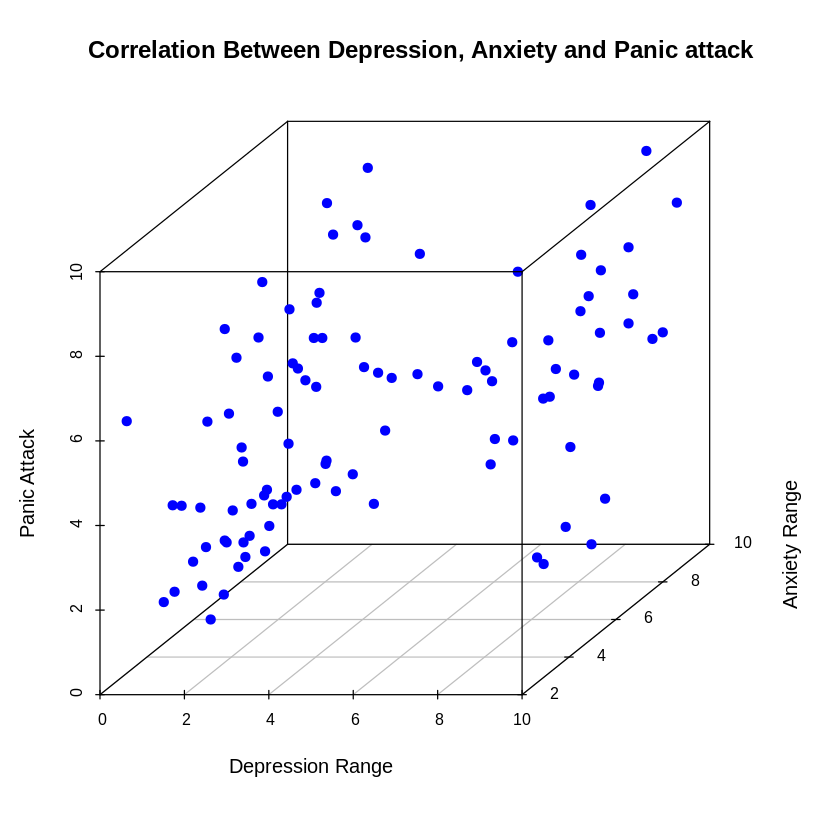

```python
#3D Scatter Plot for the Depression, Anxiety and Panic Attack
scatterplot3d(
  x = student_df$Depression.Range,
  y = student_df$Anxiety.Range,
  z = student_df$Panic.Attack.Range,
  color = "blue",
  pch = 19,  # Point shape
  main = "Correlation Between Depression, Anxiety and Panic attack",
  xlab = "Depression Range",
  ylab = "Anxiety Range",
  zlab = "Panic Attack"
)
```

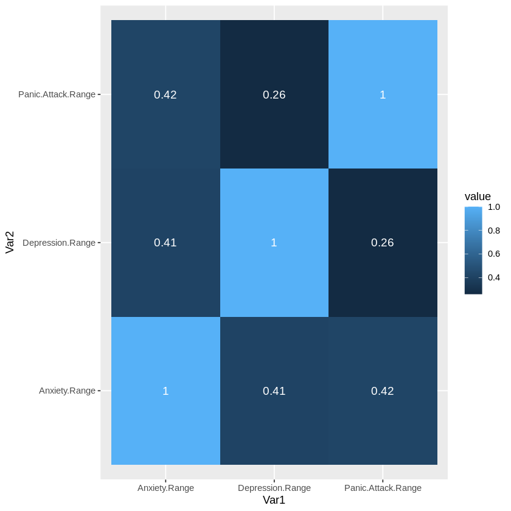

```python
 # creating correlation matrix
 data <- data.frame(student_df[c("Anxiety.Range","Depression.Range","Panic.Attack.Range")])
corr_mat <- round(cor(data),2)

# reduce the size of correlation matrix
melted_corr_mat <- melt(corr_mat)
# head(melted_corr_mat)

# plotting the correlation heatmap
library(ggplot2)
ggplot(data = melted_corr_mat, aes(x=Var1, y=Var2,
                                   fill=value)) +
geom_tile() +
geom_text(aes(label = value),
          color = "white", size = 4)
```

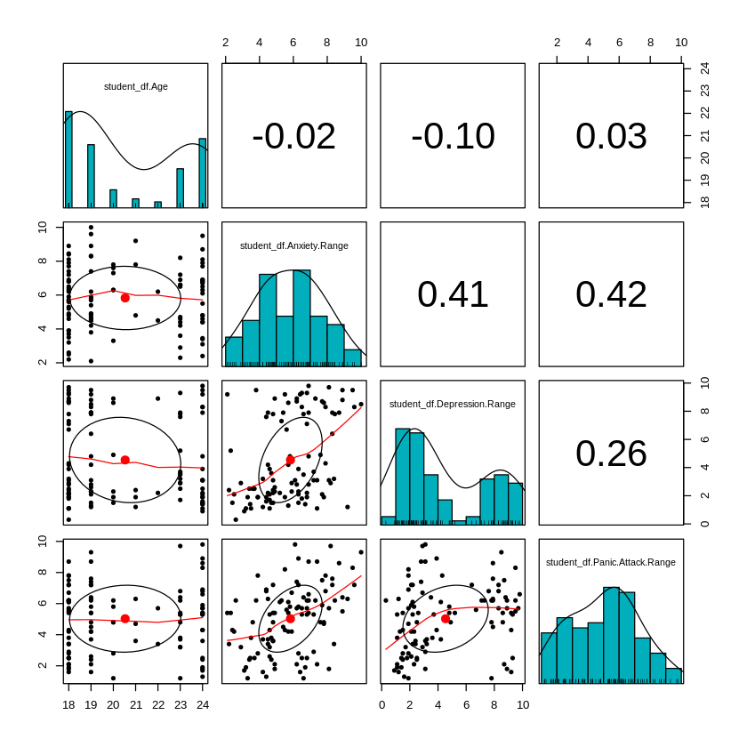

```python
#Pair panel for pairing Age, Anxiety, Depression, Panic Attack, Counselling Session
df2 <- data.frame(student_df$Age,student_df$Anxiety.Range,student_df$Depression.Range, student_df$Panic.Attack.Range, student_df$Counselling.Range)
pairs.panels(df2[,-5],
             method = "pearson", # correlation method
             hist.col = "#00AFBB",
             density = TRUE,  # show density plots
             ellipses = TRUE # show correlation ellipses
)
```

# **8. Linear Regression :**

In this section we have modelled and quantified the relationships between one or more predictor variables and the outcome variables. It assists us in understanding how changes in the predictors are related to changes in the response variable.

1. The link between the dependent variable Age and the independent variable Depression Range is specified in the first linear regression model. It denotes that we wish to predict Age using the Depression Range.
2. Based on the "Counselling.Range" independent variable, the model attempts to predict the "Updated_GPA" the response.
3. This model's purpose is to predict "Year of Study" dependent variable from "Depression.Range" the predictor variable. It means we're modeling "Year of Study" as the dependent variable and trying to figure out how "Depression.Range" effects or explains differences in "Year of Study."
4. This model's goal is to predict "Age" dependent variable from "Anxiety.Status" the predictor variable.It means we're modeling "Age" as the dependent variable and trying to figure out how "Anxiety.Status" effects or explains changes in "Age."
5. This model's objective is to forecast "Age" the response variable based on "Panic.Attack" independent variable. It means we're modeling "Age" as the dependent variable and trying to figure out how "Panic.Attack" effects or explains differences in "Age."

```python
lm_Depression <- lm(Age ~ Depression.Range, data = student_df)
summary(lm_Depression)
```

```
Call:
lm(formula = Age ~ Depression.Range, data = student_df)

Residuals:
   Min     1Q Median     3Q    Max
-2.869 -2.204 -1.206  2.729  3.886

Coefficients:
                 Estimate Std. Error t value Pr(>|t|)
(Intercept)      20.89256    0.45259  46.162   <2e-16 ***
Depression.Range -0.07942    0.08268  -0.961    0.339
---
Signif. codes:  0 ‘***’ 0.001 ‘**’ 0.01 ‘*’ 0.05 ‘.’ 0.1 ‘ ’ 1

Residual standard error: 2.497 on 98 degrees of freedom
  (1 observation deleted due to missingness)
Multiple R-squared:  0.009327,	Adjusted R-squared:  -0.0007824
F-statistic: 0.9226 on 1 and 98 DF,  p-value: 0.3392
```

```python
lm_CurrentGPA <- lm(Updated_GPA ~ Counselling.Range, data = student_df)
summary(lm_CurrentGPA)
```

```
Call:
lm(formula = Updated_GPA ~ Counselling.Range, data = student_df)

Residuals:
     Min       1Q   Median       3Q      Max
-3.07082 -0.20404  0.08614  0.36257  0.59614

Coefficients:
                  Estimate Std. Error t value Pr(>|t|)
(Intercept)        3.07082    0.11551  26.585  < 2e-16 ***
Counselling.Range  0.06661    0.02010   3.314  0.00129 **
---
Signif. codes:  0 ‘***’ 0.001 ‘**’ 0.01 ‘*’ 0.05 ‘.’ 0.1 ‘ ’ 1

Residual standard error: 0.5504 on 99 degrees of freedom
Multiple R-squared:  0.09984,	Adjusted R-squared:  0.09074
F-statistic: 10.98 on 1 and 99 DF,  p-value: 0.001287
```

```python
lm_Year <- lm(Year.of.Study  ~ Depression.Range, data = student_df)
summary(lm_Year)
```

```
Call:
lm(formula = Year.of.Study ~ Depression.Range, data = student_df)

Residuals:
     Min       1Q   Median       3Q      Max
-1.04001 -0.93884 -0.01612  0.97685  2.06397

Coefficients:
                 Estimate Std. Error t value Pr(>|t|)
(Intercept)       1.90652    0.17951  10.621   <2e-16 ***
Depression.Range  0.01405    0.03294   0.427    0.671
---
Signif. codes:  0 ‘***’ 0.001 ‘**’ 0.01 ‘*’ 0.05 ‘.’ 0.1 ‘ ’ 1

Residual standard error: 0.9986 on 99 degrees of freedom
Multiple R-squared:  0.001835,	Adjusted R-squared:  -0.008248
F-statistic: 0.182 on 1 and 99 DF,  p-value: 0.6706
```

```python
lm_Anxiety <- lm(Age ~ Anxiety.Status, data = student_df)
summary(lm_Anxiety)
```

```
Call:
lm(formula = Age ~ Anxiety.Status, data = student_df)

Residuals:
   Min     1Q Median     3Q    Max
-2.697 -2.206 -1.206  2.426  3.794

Coefficients:
                  Estimate Std. Error t value Pr(>|t|)
(Intercept)        20.6970     0.3075  67.312   <2e-16 ***
Anxiety.StatusYes  -0.4911     0.5273  -0.931    0.354
---
Signif. codes:  0 ‘***’ 0.001 ‘**’ 0.01 ‘*’ 0.05 ‘.’ 0.1 ‘ ’ 1

Residual standard error: 2.498 on 98 degrees of freedom
  (1 observation deleted due to missingness)
Multiple R-squared:  0.008772,	Adjusted R-squared:  -0.001342
F-statistic: 0.8673 on 1 and 98 DF,  p-value: 0.354
```

```python
lm_PanicAttack <- lm(Age ~ Panic.Attack, data = student_df)
summary(lm_PanicAttack)
```

```
Call:
lm(formula = Age ~ Panic.Attack, data = student_df)

Residuals:
   Min     1Q Median     3Q    Max
-2.727 -2.433 -1.433  2.567  3.567

Coefficients:
                Estimate Std. Error t value Pr(>|t|)
(Intercept)      20.4328     0.3060  66.764   <2e-16 ***
Panic.AttackYes   0.2944     0.5328   0.553    0.582
---
Signif. codes:  0 ‘***’ 0.001 ‘**’ 0.01 ‘*’ 0.05 ‘.’ 0.1 ‘ ’ 1

Residual standard error: 2.505 on 98 degrees of freedom
  (1 observation deleted due to missingness)
Multiple R-squared:  0.003107,	Adjusted R-squared:  -0.007065
F-statistic: 0.3054 on 1 and 98 DF,  p-value: 0.5817
```

# **9. Multiple Linear Regression :**

This Regression model is to predict "Updated_GPA" which is the dependent variable using two predictor variables: "GPA" and "Counselling.Range."It means we're modeling "Updated_GPA" as the dependent variable and trying to figure out how "GPA" and "Counselling.Range" influence or explain differences in "Updated_GPA."

These plots allow you to evaluate how well the data points correspond with the linear regression lines and display and assess the linear correlations between distinct pairs of variables (GPA vs. Counselling Range and Counselling Range vs. Updated GPA). The regression lines reveal the degree and direction of the correlations between these variables.

```python
mulreg2 <- lm(Updated_GPA ~ GPA+ Counselling.Range, data = student_df)
summary(mulreg2)
```

```
Call:
lm(formula = Updated_GPA ~ GPA + Counselling.Range, data = student_df)

Residuals:
     Min       1Q   Median       3Q      Max
-0.85068 -0.11673 -0.00719  0.10815  0.75474

Coefficients:
                  Estimate Std. Error t value Pr(>|t|)
(Intercept)       0.850677   0.112256   7.578 1.99e-11 ***
GPA               0.704074   0.032199  21.867  < 2e-16 ***
Counselling.Range 0.076917   0.008346   9.216 6.09e-15 ***
---
Signif. codes:  0 ‘***’ 0.001 ‘**’ 0.01 ‘*’ 0.05 ‘.’ 0.1 ‘ ’ 1

Residual standard error: 0.2281 on 98 degrees of freedom
Multiple R-squared:  0.8469,	Adjusted R-squared:  0.8438
F-statistic:   271 on 2 and 98 DF,  p-value: < 2.2e-16
```

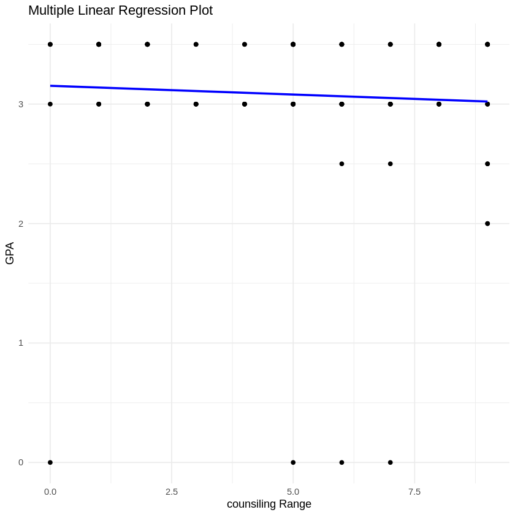

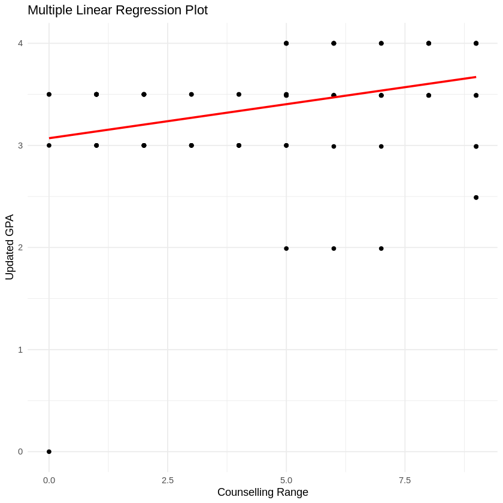

```python
ggplot(student_df, aes(x = Counselling.Range, y = GPA)) +
  geom_point() +
  geom_smooth(method = "lm", formula = y ~ x, se = FALSE, color = "blue") +
  labs(title = "Multiple Linear Regression Plot",x = "counsiling Range",y = "GPA") + theme_minimal()
#second plot
ggplot(student_df, aes(x = Counselling.Range, y = Updated_GPA)) +
  geom_point() + geom_smooth(method = "lm", formula = y ~ x, se = FALSE, color = "red") +
  labs(title = "Multiple Linear Regression Plot", x = "Counselling Range", y = "Updated GPA") +theme_minimal()
```

# **10. Report :**

The Student Mental Health project aims to study and analyse the Students current academic situation and predict their Stress levels based on their Age, Depression Status, Anxiety Status and Panic Attack Status. Additionally, how ouselling sessions helped the students to improve their academic scores.

**Data Gathering:** Surveys and questionnaires were handed to students on campus/universities to collect data. Stress levels, anxiety, depression, academic pressures, and access to mental health resources were among the issues covered in the surveys.

**Data Preparation:** Preprocessing of collected data included data cleansing, addressing missing responses, and encoding categorical variables. This made certain that the dataset was ready for the analysis. Since the data was collected by a survey, there wasn't any duplicacy in the data.

**Data Exploration EDA (exploratory data analysis) :**

To acquire more insight into the mental health state of Students, exploratory data analysis was performed. Visualizations such as pie chart, bar graph, Density Graph, histograms, scatter plots, correlation, Simple and Multiple regression were utilized to identify patterns and correlations between the variables.

**Data Visualization**

We have created multiple distinct graphs to get deeper insights and graphical representation of the data and their values where -

1. Pie chart represents the Gender Distribution.
2. Density Plot shows the Depression Range.
3. Histogram displays the Age distribution.
4. Bar Graph illustrates the most enrolled Courses.

**Data Correlation**

This gave the glimpse of the relationship between two quantitative variables by using various techniques and identified the correlation amongst them. And the relation demonstration is performed in the form of various different plots i.e. Box Plot which illustrates the relation between the Anxiety Range and Panic Attack Range.

Scatter Line Plot demonstrates the correlation with the Counselling Session range and the Updated GPA.

3D Scatter Plot gives the glimpse of the correlation between three variables Depression, Anxiety and Panic attack.

Heatmap displays the graphical representation with calculated values for Depression, Anxiety and Panic Attacks and defines the relationship between these variables.

**Regression Models**

**1. Simple Linear Regression**

we have modelled and quantified the relationships between one or more independent variables and the dependent variables. It assists us in understanding how changes in the predictors are related to changes in the response variable.

**2. Multiple Linear Regression**

This Regression model is to predict "Updated_GPA" which is the dependent variable using two independent variables: "GPA" and "Counselling.Range."

It means we're modeling "Updated_GPA" as the dependent variable and trying to figure out how "GPA" and "Counselling.Range" influence or explain differences in "Updated_GPA."

**Plots**

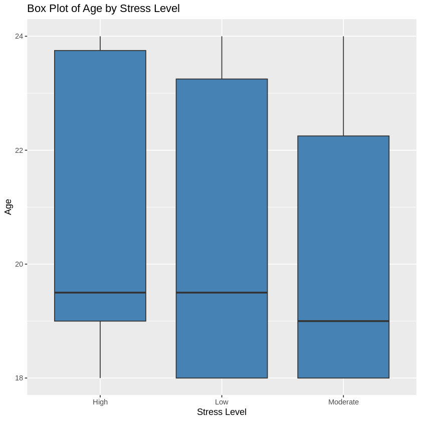

```python
ggplot(student_df, aes(x = Stress_level, y = Age)) +
  geom_boxplot(fill = "steelblue") +
  labs(title = "Box Plot of Age by Stress Level", x = "Stress Level", y = "Age")
```

[figure not shown]

```python
ggplot(student_df, aes(x = Gender, y = Depression.Range)) +
  stat_summary(fun = "mean", geom = "bar", fill = "LightGreen") +
  labs(title = "Bar Plot of Gender by Depression Range", x = "Gender", y = "Depression Range")
```

**Recommendation :**

We would strongly like to recommend below points to our stakeholder to be considered.

- The State should conduct social awareness camps regarding mental Health and provide free Counselling sessions which will be anonymous.
- The State should also provide assistance to the Schools and Universities to have a health care center which will help and accomodate Counselling Sessions every quarter.

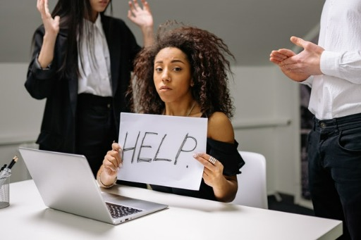

**References :**

1. Zybooks
2. Kaggle
3. GeeksforGeeks
4. ChatGPT